# DS 202 - Homework #2

Gavin Herum

## Swiss Banknotes

1. Download the RMarkdown file with these homework instructions to use as a template for your work. Make sure to replace “Your Name” in the YAML with your name.
2. The R package `mclust` contains a data set called `banknote`, consisting of (physical) measurements on 200 Swiss bank notes, 100 of which are genuine, while the other half is counterfeit. Load this data set (you might have to install the package) using the code below.

```r
# install.packages("mclust")
library(mclust) # if this throws an error of the form 'there is no package called mcmclust', uncomment the line above, run it once, then comment the line out again and run the code chunk again.
data(banknote)
```

3. (1 pt) Use one of our object inspecting functions and interpret the result in the data that you see.

   ```r
   names(banknote)
   ```

   ```
   ## [1] "Status"   "Length"   "Left"     "Right"    "Bottom"   "Top"      "Diagonal"
   ```

   ```r
   banknote
   ```

   [output cut: 186 more lines]

4. (1 pt) Use the package `ggplot2` to draw a barchart of `Status`. Map `Status` to the fill color of the barchart.

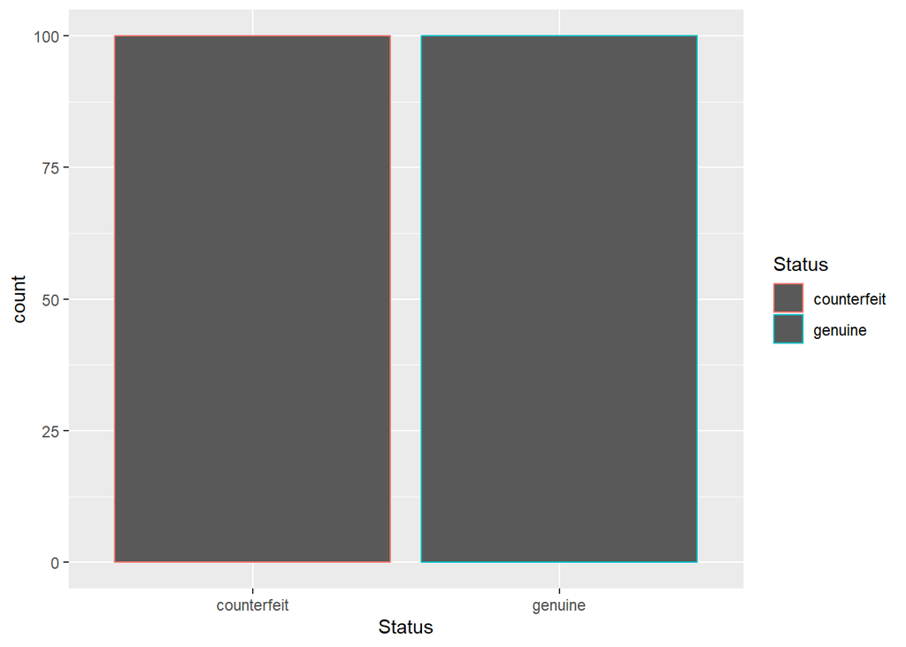

   ```r
   library(ggplot2)
   ggplot(banknote, aes(Status, colour=Status)) + geom_bar()
   ```

5. (1 pt) Use the package `ggplot2` to draw a histogram of one of the variables in the dataset that shows a distinction between genuine and counterfeit banknotes. Use fill color to show this difference. Choose the binwidth such that there are no gaps in the middle range of the histogram.

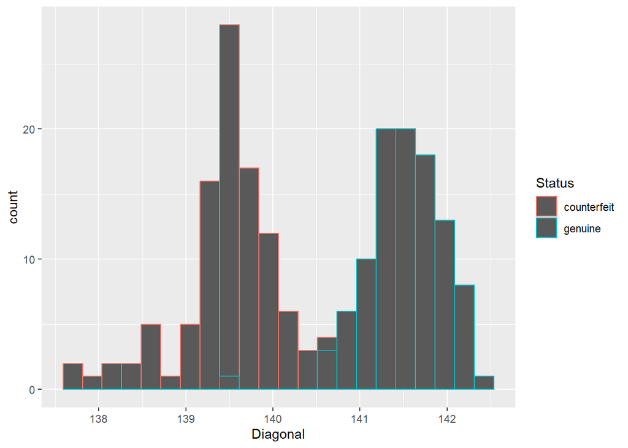

   ```r
   library(ggplot2)
   ggplot(banknote, aes(x=Diagonal, colour=Status)) + geom_histogram(binwidth = 0.225)
   ```

6. (1 pt) Use the package `ggplot2` to draw a scatterplot of two (continuous) measurements, color by `Status`. Find a pair of measurements that allow you to separate perfectly between genuine and counterfeit banknotes.

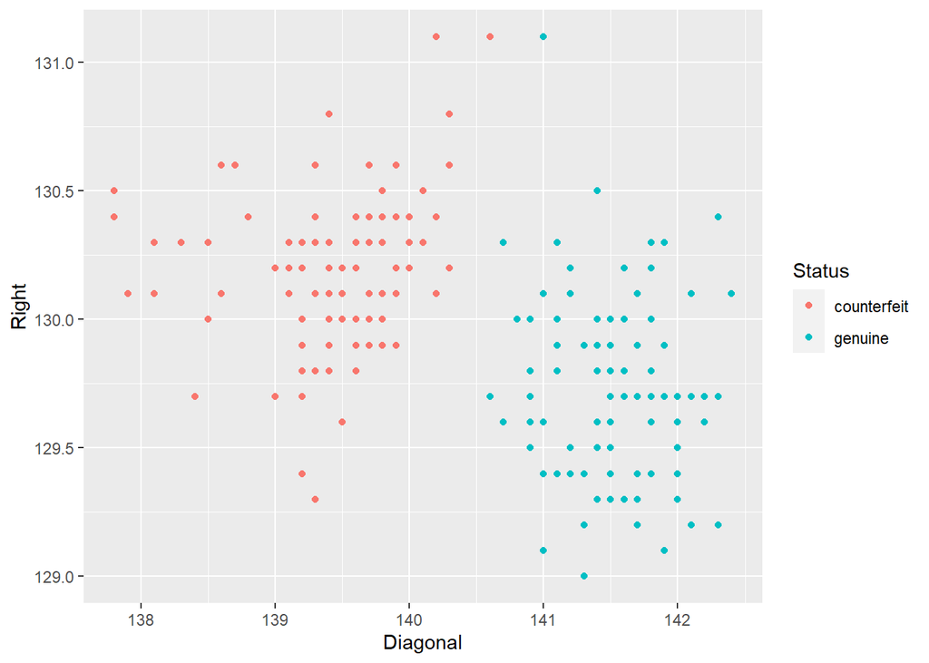

   ```r
   library(ggplot2)
   ggplot(banknote, aes(x=Diagonal, y=Right, colour=Status)) + geom_point()
   ```

7. (4.5 pts) For each of the three figures above, write a three sentence summary, describing the
   1. **structure of the plot**: what type of plot is it? Which variables are mapped to x, to y, and to the (fill) color?

      Bar: the main finding is that there are an equal number of counterfeit and genuine banknotes in the data set

      Histogram: the main finding is that there are distinct differences in the counterfeit and genuine banknotes and that diagonal is a good way to separate the different types of bank notes.

      Scatter: the main finding is that the dimensions of the note are a key sign of whether a bank note is counterfeit or genuine and that given these stats there is a really high prediction rate of authentication.
   3. **additional message**: point out anomalies or outliers, if there are any.

      Bar: there is no outliers

      Histogram: there are some anomalies with a couple of genuine notes being lower than expected

      Scatter: in large part everything is separated nicely, there is one genuine note that has a much higher Right than what would be expected, and some spread on the counterfeit notes in terms of Diagonal.
8. (1.5 pts) Ensure that your submission is reproducible. We will load your Rmd file into RStudio and knit it. This should match your submitted html/word file

For the submission: submit your solution in an R Markdown file. Also submit the corresponding html/word file with it.